# BellhopJL

| **Model** | `AcousticsToolbox.BellhopJL` |
| --- | --- |
| **Description** | Native Julia port of the [Bellhop ray/beam tracer](https://oalib-acoustics.org/models-and-software/rays/) |
| **Language** | Julia |
| **Advantages** | Differentiable (forward mode), no file I/O, drop-in alternative to `AcousticsToolbox.Bellhop` |
| **Limitations** | 2D only, no 3D or range-dependent sound speed support |
| **Differentiability** | `ForwardDiff` |

```
BellhopJL(env; kwargs...)
```

Native-Julia port of the 2D Bellhop Gaussian-beam/ray tracer — a drop-in alternative to the Fortran-wrapping `Bellhop` model in this package, differentiable with ForwardDiff.

Supported keyword arguments:

- `nbeams`: number of beams to use (default: 0, auto)
- `min_angle`: minimum beam angle (default: -80°)
- `max_angle`: maximum beam angle (default: 80°)
- `beam_type`: `:geometric` (default) or `:gaussian`
- `threads`: number of threads for the beam loop (default: `Threads.nthreads()`; 1 runs the serial code path)

`BellhopJL` is a native Julia port of the 2D Bellhop Gaussian beam / ray tracer, based on the [A-New-BellHope](https://github.com/A-New-BellHope/bellhop) bug-fixed mirror of Bellhop 2022_4 and updated with the relevant corrections from the OALIB 2024_12_25 release (full provenance and deviations are documented in the package’s [`PORTING_NOTES.md`](https://github.com/org-arl/AcousticsToolbox.jl/blob/master/src/bellhopjl/PORTING_NOTES.md)). It implements Bellhop’s exact stepping algorithm, boundary reflections, and geometric hat/Gaussian beam influence in Cartesian coordinates, and reads environments directly from `UnderwaterAcoustics.jl` (no env/shd/arr file I/O). Since the port is pure Julia, it is compatible with automatic differentiation (AD) tools such as `ForwardDiff` (prefer `beam_type=:gaussian` for optimization work, as hat beams have kinks at beam edges).

A good overview of the Bellhop model can be found at:

- O. C. Rodríguez, “General description of the BELLHOP ray tracing program (June 2008 release)”, Technical report, v1.0, Universidade do Algarve, 2008 [(pdf)](http://oalib.hlsresearch.com/Rays/GeneralDescription.pdf).

## Example

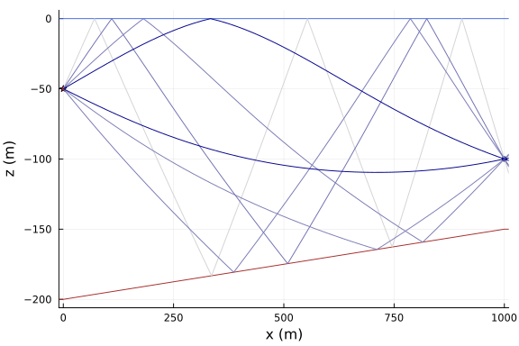

```julia
using UnderwaterAcoustics
using AcousticsToolbox
using Plots

env = UnderwaterEnvironment(
  bathymetry = SampledField([200, 150]; x=[0, 1000], interp=Linear()),
  soundspeed = SampledField([1500, 1480, 1495, 1510, 1520]; z=0:-50:-200, interp=CubicSpline()),
  seabed = SandyClay
)
pm = BellhopJL(env)

tx = AcousticSource(0, -50, 300)
rx = AcousticReceiver(1000, -100)
rays = arrivals(pm, tx, rx)

plot(env; xlims=(-10, 1010))
plot!(tx)
plot!(rx)
plot!(rays)
```

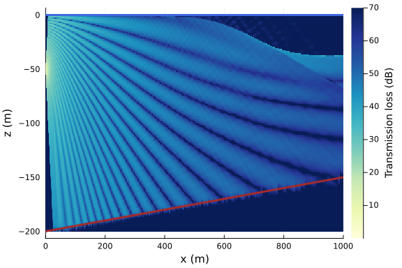

```julia
rxs = AcousticReceiverGrid2D(1:1000, -200:0)
x = transmission_loss(pm, tx, rxs; mode=:coherent)

plot(rxs, x; crange=70)
plot!(env; xlims=(0,1000), linewidth=3)
```

## Notes

The `BellhopJL` propagation model requires that the transmitter is located at $(x=0, y=0)$ and all receivers are located in the right half-plane (i.e., $x>0$ and $y=0$). This limitation can be worked around by wrapping the model with `Reframe2D`, which automatically transforms 2D scenarios specified in world coordinates into the coordinate system required by the model (see the quickstart guide for an example).

Like the Fortran wrapper, the port implements the subset of Bellhop features reachable through the `UnderwaterAcoustics.jl` API. It does NOT support:

- 3D environments (i.e., Bellhop 3D)
- Range-dependent sound speed
- Directional or line sources
- Cerveny (Cartesian or ray-centered) and simple Gaussian bundle beams

**Licensing:** the `BellhopJL` solver is GPL-3.0-or-later (a derivative work of Bellhop), unlike the rest of `AcousticsToolbox.jl` (MIT) — see the package’s [licensing notes](https://github.com/org-arl/AcousticsToolbox.jl#licensing) for details.